# Title

```r
web_arundel %>% filter(percentage_white >= 0)
```

```
## Simple feature collection with 104 features and 9 fields
## Geometry type: MULTIPOLYGON
## Dimension:     XY
## Bounding box:  xmin: -8553830 ymin: 4680608 xmax: -8504197 ymax: 4755734
## Projected CRS: WGS 84 / Pseudo-Mercator
## First 10 features:
##          GEOID                                                NAME total_popE
## 1  24003750203 Census Tract 7502.03, Anne Arundel County, Maryland       1403
## 2  24003730204 Census Tract 7302.04, Anne Arundel County, Maryland       6412
## 3  24003731004 Census Tract 7310.04, Anne Arundel County, Maryland       4409
## 4  24003750202 Census Tract 7502.02, Anne Arundel County, Maryland       3621
## 5  24003701200    Census Tract 7012, Anne Arundel County, Maryland       8031
## 6  24003730603 Census Tract 7306.03, Anne Arundel County, Maryland       3102
## 7  24003740303 Census Tract 7403.03, Anne Arundel County, Maryland       4237
## 8  24003730506 Census Tract 7305.06, Anne Arundel County, Maryland       3358
```

[output cut: 24 more lines]

```r
biclass_arundel <-  bi_class(web_arundel, x = percentage_white, y = incomeE, style = "quantile", dim = 2)
```

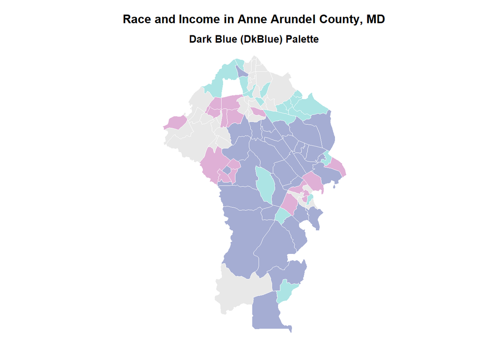

```r
#plot using the biclass category
map2 <- ggplot() +
  geom_sf(data = biclass_arundel, mapping = aes(fill = bi_class), color = "white", size = 0.1, show.legend = FALSE) +
  bi_scale_fill(pal = "DkBlue", dim = 3) +
  labs(
    title = "Race and Income in Anne Arundel County, MD",
    subtitle = "Dark Blue (DkBlue) Palette"
  ) +
  bi_theme() +
  theme(plot.title = element_text(size=12)) +
  theme(plot.subtitle = element_text(size=10))
plot(map2)
```

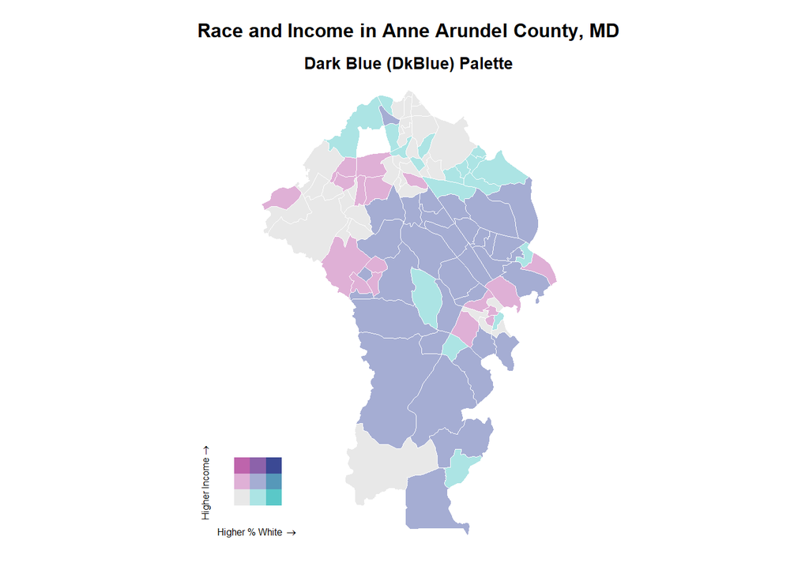

```r
#add legend
legend2 <- bi_legend(pal = "DkBlue",
                    dim = 3,
                    xlab = "Higher % White ",
                    ylab = "Higher Income ",
                    size = 6)

# combine map with legend
finalPlot2 <- ggdraw() +
  draw_plot(map2, 0, 0, 1, 1) +
  draw_plot(legend2, 0.2, .05, 0.2, 0.2)

# plot variable containing map and legend
plot(finalPlot2)
```

**8. Write the bi_class output to a geojson file. (1 points)**

```r
st_write(biclass_arundel, 'Anne_Arundel_biclass_race_pop.geojson', append = TRUE)
```

```
## Updating layer `Anne_Arundel_biclass_race_pop' to data source `Anne_Arundel_biclass_race_pop.geojson' using driver `GeoJSON'
## Updating existing layer Anne_Arundel_biclass_race_pop
## Writing 105 features with 10 fields and geometry type Multi Polygon.
```

**9. Now open your geojson output and create a QGIS map of your bivariate map. Put an image of that map here. (2 points)**

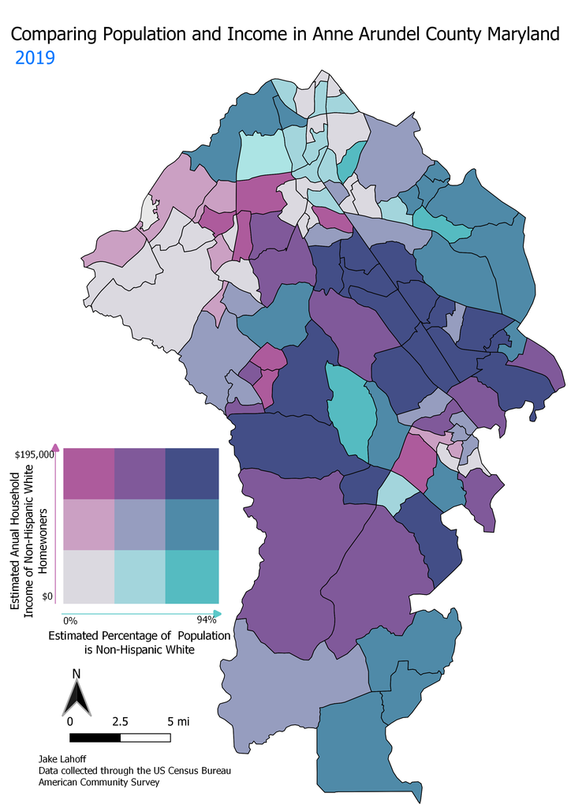

**10. Use qgis2web and put a link here to your github site with the webmap of your bivariate map. (3 points)** Github front end: https://jake-lahoff.github.io/lab_8/ Github back end: https://github.com/Jake-Lahoff/Jake-Lahoff.github.io/tree/master/lab_8

## 3. Reflection (3 points)

This assignment was very helpful in continuing to learn to code and process in R. Particularly the use of the biclass tool and the bivariate legend tool. The use of those tools and turning them into a map was also helpful in furthering my ability to create presentable data in R.

I am confident with the tidycensus code, but would like to keep working with the plotting and legend tools to continue to display my maps in an efficient manner

The trickiest part for this lab was making the bivariate color scheme line up. I had to experiment with different styles and diffrent splits to make the data displayable. I also had some trouble filtering out maximums in data sets, but was able to find the results by filtering by a threshold to get a fewer number of outputs first.

## 4. Extra Credit (2 points)

**Put an image as a legend in your web map.**

Knit your document to a .html file. Submit this knitted document.